# WEEK13

UNIVARIATE ANALYSIS

```r
# Checking the mean , median, max and min in our continuous columns.

summary(df)
```

```
##  Administrative  Administrative_Duration Informational
##  Min.   : 0.00   Min.   :  -1.00         Min.   : 0.0000
##  1st Qu.: 0.00   1st Qu.:   0.00         1st Qu.: 0.0000
##  Median : 1.00   Median :   9.00         Median : 0.0000
##  Mean   : 2.34   Mean   :  81.68         Mean   : 0.5088
##  3rd Qu.: 4.00   3rd Qu.:  94.75         3rd Qu.: 0.0000
##  Max.   :27.00   Max.   :3398.75         Max.   :24.0000
##  Informational_Duration ProductRelated   ProductRelated_Duration
##  Min.   :  -1.00        Min.   :  0.00   Min.   :   -1.0
##  1st Qu.:   0.00        1st Qu.:  8.00   1st Qu.:  193.6
##  Median :   0.00        Median : 18.00   Median :  609.5
##  Mean   :  34.84        Mean   : 32.06   Mean   : 1207.5
##  3rd Qu.:   0.00        3rd Qu.: 38.00   3rd Qu.: 1477.6
##  Max.   :2549.38        Max.   :705.00   Max.   :63973.5
##   BounceRates        ExitRates         PageValues        SpecialDay
##  Min.   :0.00000   Min.   :0.00000   Min.   :  0.000   Min.   :0.00000
##  1st Qu.:0.00000   1st Qu.:0.01422   1st Qu.:  0.000   1st Qu.:0.00000
##  Median :0.00293   Median :0.02500   Median :  0.000   Median :0.00000
##  Mean   :0.02045   Mean   :0.04150   Mean   :  5.952   Mean   :0.06197
##  3rd Qu.:0.01667   3rd Qu.:0.04848   3rd Qu.:  0.000   3rd Qu.:0.00000
##  Max.   :0.20000   Max.   :0.20000   Max.   :361.764   Max.   :1.00000
##     Month           OperatingSystems    Browser           Region
##  Length:12199       Min.   :1.000    Min.   : 1.000   Min.   :1.000
##  Class :character   1st Qu.:2.000    1st Qu.: 2.000   1st Qu.:1.000
##  Mode  :character   Median :2.000    Median : 2.000   Median :3.000
##                     Mean   :2.124    Mean   : 2.358   Mean   :3.153
##                     3rd Qu.:3.000    3rd Qu.: 2.000   3rd Qu.:4.000
##                     Max.   :8.000    Max.   :13.000   Max.   :9.000
##   TrafficType     VisitorType         Weekend         Revenue
##  Min.   : 1.000   Length:12199       Mode :logical   Mode :logical
##  1st Qu.: 2.000   Class :character   FALSE:9343      FALSE:10291
##  Median : 2.000   Mode  :character   TRUE :2856      TRUE :1908
##  Mean   : 4.075
##  3rd Qu.: 4.000
##  Max.   :20.000
```

From our summary we notice that we have the minimum time expressed as a negative number. This is an anomaly. Zero is the baseline. We are therefore going to drop -1 in all our time columns.

```r
# Dropping the obvious anomaly.
df<-subset(df, Administrative_Duration!=-1)
summary(df)
```

```
##  Administrative   Administrative_Duration Informational
##  Min.   : 0.000   Min.   :   0.00         Min.   : 0.0000
##  1st Qu.: 0.000   1st Qu.:   0.00         1st Qu.: 0.0000
##  Median : 1.000   Median :  10.00         Median : 0.0000
##  Mean   : 2.346   Mean   :  81.91         Mean   : 0.5102
##  3rd Qu.: 4.000   3rd Qu.:  95.00         3rd Qu.: 0.0000
##  Max.   :27.000   Max.   :3398.75         Max.   :24.0000
##  Informational_Duration ProductRelated   ProductRelated_Duration
##  Min.   :   0.00        Min.   :  0.00   Min.   :    0.0
##  1st Qu.:   0.00        1st Qu.:  8.00   1st Qu.:  196.5
##  Median :   0.00        Median : 18.00   Median :  612.8
##  Mean   :  34.93        Mean   : 32.14   Mean   : 1210.8
##  3rd Qu.:   0.00        3rd Qu.: 38.00   3rd Qu.: 1481.8
##  Max.   :2549.38        Max.   :705.00   Max.   :63973.5
##   BounceRates         ExitRates         PageValues        SpecialDay
##  Min.   :0.000000   Min.   :0.00000   Min.   :  0.000   Min.   :0.00000
##  1st Qu.:0.000000   1st Qu.:0.01418   1st Qu.:  0.000   1st Qu.:0.00000
##  Median :0.002865   Median :0.02500   Median :  0.000   Median :0.00000
##  Mean   :0.020009   Mean   :0.04110   Mean   :  5.969   Mean   :0.06201
##  3rd Qu.:0.016324   3rd Qu.:0.04812   3rd Qu.:  0.000   3rd Qu.:0.00000
##  Max.   :0.200000   Max.   :0.20000   Max.   :361.764   Max.   :1.00000
##     Month           OperatingSystems    Browser           Region
##  Length:12166       Min.   :1.000    Min.   : 1.000   Min.   :1.000
##  Class :character   1st Qu.:2.000    1st Qu.: 2.000   1st Qu.:1.000
##  Mode  :character   Median :2.000    Median : 2.000   Median :3.000
##                     Mean   :2.125    Mean   : 2.358   Mean   :3.152
##                     3rd Qu.:3.000    3rd Qu.: 2.000   3rd Qu.:4.000
##                     Max.   :8.000    Max.   :13.000   Max.   :9.000
##   TrafficType     VisitorType         Weekend         Revenue
##  Min.   : 1.000   Length:12166       Mode :logical   Mode :logical
##  1st Qu.: 2.000   Class :character   FALSE:9313      FALSE:10258
##  Median : 2.000   Mode  :character   TRUE :2853      TRUE :1908
##  Mean   : 4.076
##  3rd Qu.: 4.000
##  Max.   :20.000
```

```r
# Checking the size of data we will work with.
dim(df)
```

```
## [1] 12166    18
```

We still have enough data to work with.

RANGE

Range tells us the scale of our data from the minimum to the maximum value.

```r
range(df[,1])
```

```
## [1]  0 27
```

```r
range(df[,2])
```

```
## [1]    0.00 3398.75
```

```r
range(df[,3])
```

```
## [1]  0 24
```

```r
range(df[,4])
```

```
## [1]    0.000 2549.375
```

```r
range(df[,5])
```

```
## [1]   0 705
```

STANDARD DEVIATION

The standard deviation tells us the spread of data from the mean. A low standard deviation indicates that our data points are clustered around the mean while a high standard deviation indicates that the data points are widely spread out.

```r
sd(df[,1])
```

```
## [1] 3.333224
```

```r
sd(df[,2])
```

```
## [1] 177.7165
```

```r
sd(df[,3])
```

```
## [1] 1.277271
```

```r
sd(df[,4])
```

```
## [1] 141.6379
```

```r
sd(df[,5])
```

```
## [1] 44.63198
```

INTERQUARTILE RANGE

IQR is a measure of how far apart the middle 50% of data spreads in value.It is derived from the difference between the upper quartile(Q3) and lower quartile(Q1). A smaller value indicates that there are a lot of values centered in the middle 50% of data.

```r
IQR(df[,1])
```

```
## [1] 4
```

```r
IQR(df[,2])
```

```
## [1] 95
```

```r
IQR(df[,3])
```

```
## [1] 0
```

```r
IQR(df[,4])
```

```
## [1] 0
```

```r
IQR(df[,5])
```

```
## [1] 30
```

GRAPHICAL ANALYSIS

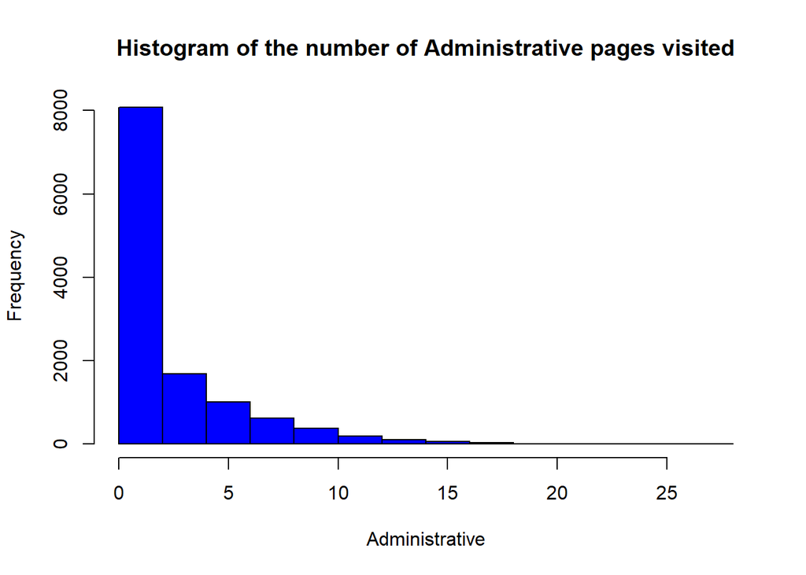

```r
hist(df[,1], main='Histogram of the number of Administrative pages visited',xlab='Administrative',col='blue')
```

Most people who visited the site visited at most 2 Administrative pages.

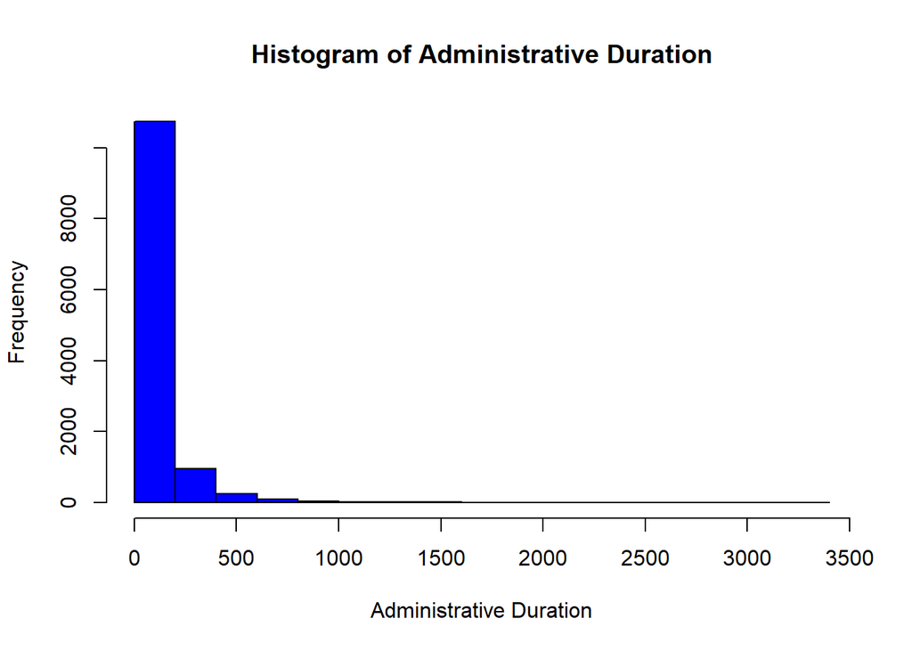

```r
hist(df[,2], main='Histogram of Administrative Duration',xlab='Administrative Duration',col='blue')
```

Most people who visited the Administrative page spent 0 to 200 seconds on the page.

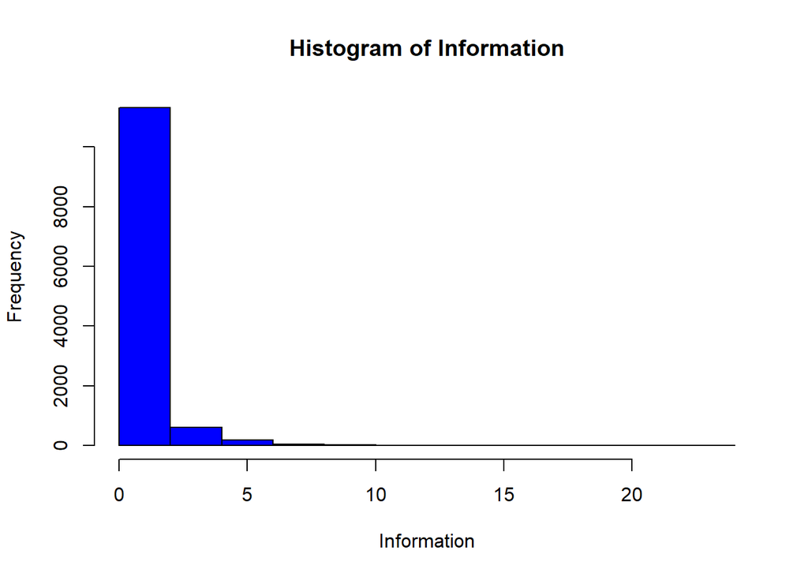

```r
hist(df[,3], main='Histogram of Information',xlab='Information',col='blue')
```

Most people who visited the site visited 0 to 2 information pages.

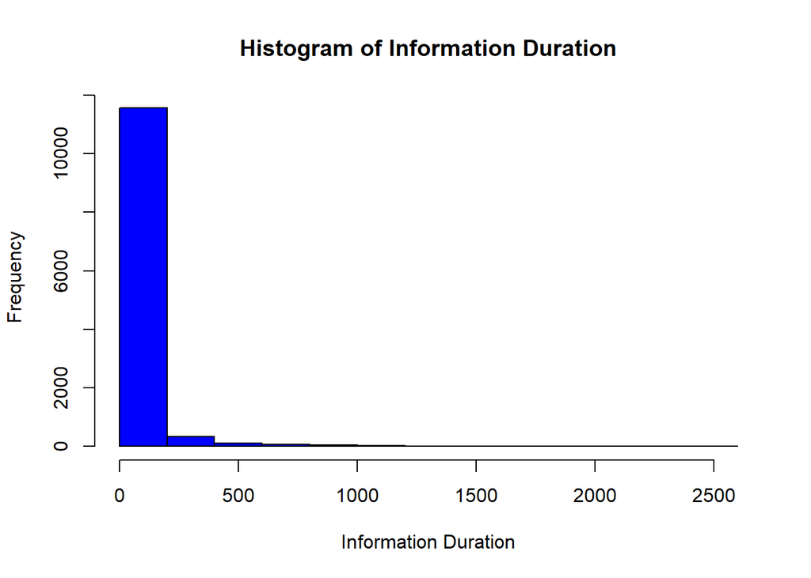

```r
hist(df[,4], main='Histogram of Information Duration',xlab='Information Duration',col='blue')
```

Most people who visited the information page spent between 0 to 200 seconds on the page.

```r
# Finding the month with the highest number of people visiting the site.
Month<- df$Month
Month.frequency<-table(Month)
Month.frequency
```

```
## Month
##  Aug  Dec  Feb  Jul June  Mar  May  Nov  Oct  Sep
##  433 1706  169  431  285 1843 3322 2980  549  448
```

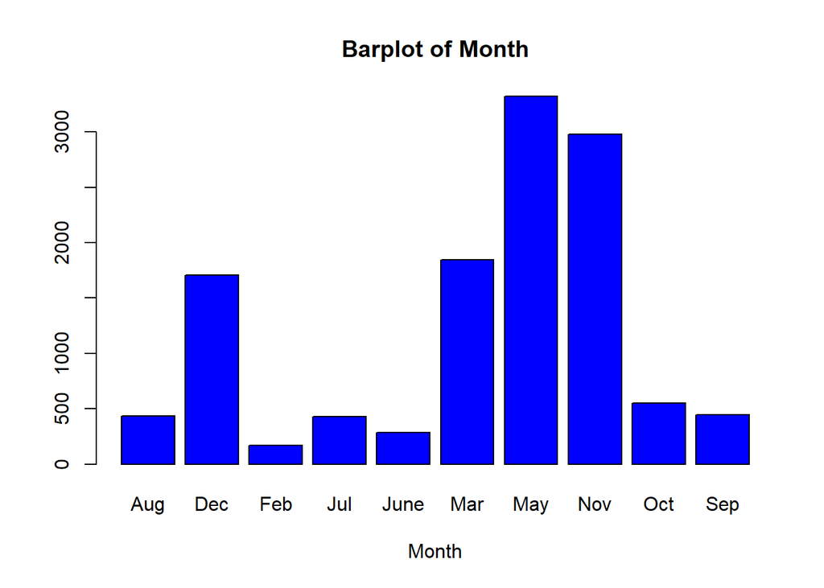

```r
barplot(Month.frequency, main='Barplot of Month', xlab='Month',col='blue')
```

May and November had the highest number of people visiting the site.

```r
# Checking the date with the highest number of people visiting the page.
Weekend<-df$Weekend
Weekend.frequency<-table(Weekend)
Weekend.frequency
```

```
## Weekend
## FALSE  TRUE
##  9313  2853
```

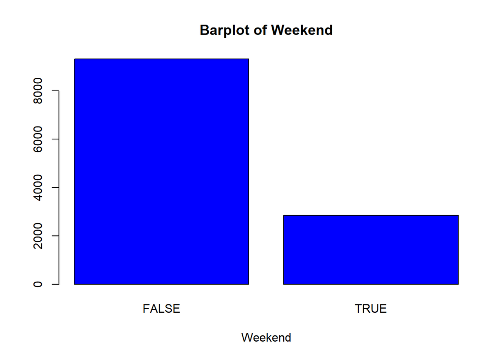

```r
barplot(Weekend.frequency, main='Barplot of Weekend', xlab='Weekend',col='blue')
```

Most people visited the site on weekdays than on weekends.

```r
# Checking the number of people who bought the brand.
Revenue<-df$Revenue
Revenue.frequency<-table(Revenue)
Revenue.frequency
```

```
## Revenue
## FALSE  TRUE
## 10258  1908
```

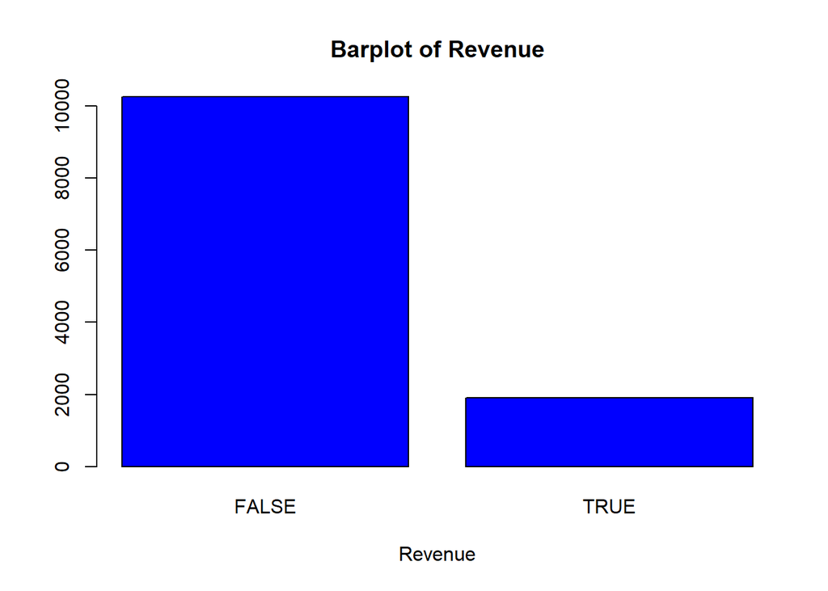

```r
barplot(Revenue.frequency, main='Barplot of Revenue', xlab='Revenue',col='blue')
```

Most people who visited the site did not buy the brand.

```r
# Checking the visitor type who mostly visited on the site.
Visitor<-df$VisitorType
Visitor.frequency<-table(Visitor)
Visitor.frequency
```

```
## Visitor
##       New_Visitor             Other Returning_Visitor
##              1693                81             10392
```

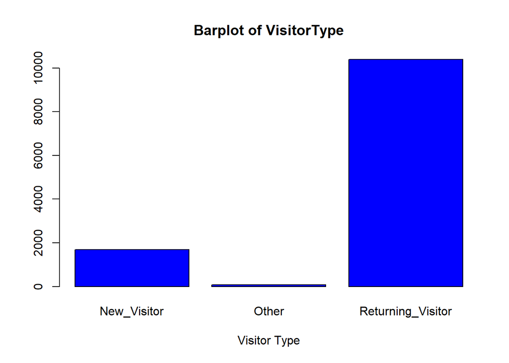

```r
barplot(Visitor.frequency, main='Barplot of VisitorType', xlab='Visitor Type',col='blue')
```

Most people who visited the site had visited the site before.

BIVARIATE ANALYSIS

```r
# Checking for correlation in our variables.
numerical<-df[,1:15]
numerical$Month<-NULL
head(numerical)
```

```
##   Administrative Administrative_Duration Informational Informational_Duration
## 1              0                       0             0                      0
## 2              0                       0             0                      0
## 4              0                       0             0                      0
## 5              0                       0             0                      0
## 6              0                       0             0                      0
## 9              0                       0             0                      0
##   ProductRelated ProductRelated_Duration BounceRates ExitRates PageValues
## 1              1                0.000000  0.20000000 0.2000000          0
## 2              2               64.000000  0.00000000 0.1000000          0
## 4              2                2.666667  0.05000000 0.1400000          0
## 5             10              627.500000  0.02000000 0.0500000          0
## 6             19              154.216667  0.01578947 0.0245614          0
## 9              2               37.000000  0.00000000 0.1000000          0
##   SpecialDay OperatingSystems Browser Region TrafficType
## 1        0.0                1       1      1           1
## 2        0.0                2       2      1           2
## 4        0.0                3       2      2           4
## 5        0.0                3       3      1           4
## 6        0.0                2       2      1           3
## 9        0.8                2       2      2           3
```

```r
# Creating a correlation matrix
numerical.cor=cor(numerical)
numerical.cor
```

```
##                         Administrative Administrative_Duration Informational
## Administrative             1.000000000             0.600107001   0.374868879
## Administrative_Duration    0.600107001             1.000000000   0.301085967
## Informational              0.374868879             0.301085967   1.000000000
## Informational_Duration     0.254501338             0.236960134   0.618591171
## ProductRelated             0.427454420             0.286176559   0.372176469
## ProductRelated_Duration    0.370295487             0.353012111   0.385693234
## BounceRates               -0.211230505            -0.135523852  -0.107784001
## ExitRates                 -0.310046147            -0.201006860  -0.158478970
## PageValues                 0.096403937             0.065793732   0.047061652
## SpecialDay                -0.097328886            -0.074906496  -0.049501655
## OperatingSystems          -0.006837685            -0.007711014  -0.009715636
## Browser                   -0.025573805            -0.015706108  -0.038707868
## Region                    -0.006969510            -0.006560783  -0.030378580
## TrafficType               -0.035117769            -0.015273092  -0.035385764
##                         Informational_Duration ProductRelated
## Administrative                     0.254501338    0.427454420
## Administrative_Duration            0.236960134    0.286176559
## Informational                      0.618591171    0.372176469
## Informational_Duration             1.000000000    0.278791062
## ProductRelated                     0.278791062    1.000000000
## ProductRelated_Duration            0.346364430    0.860147122
## BounceRates                       -0.069069152   -0.190640970
## ExitRates                         -0.102252201   -0.284503627
## PageValues                         0.029851626    0.053555453
## SpecialDay                        -0.031368255   -0.026097045
## OperatingSystems                  -0.009810886    0.003964931
## Browser                           -0.019559170   -0.013499300
## Region                            -0.027868056   -0.039929891
## TrafficType                       -0.025290621   -0.044688301
##                         ProductRelated_Duration   BounceRates    ExitRates
## Administrative                      0.370295487 -2.112305e-01 -0.310046147
## Administrative_Duration             0.353012111 -1.355239e-01 -0.201006860
## Informational                       0.385693234 -1.077840e-01 -0.158478970
## Informational_Duration              0.346364430 -6.906915e-02 -0.102252201
## ProductRelated                      0.860147122 -1.906410e-01 -0.284503627
## ProductRelated_Duration             1.000000000 -1.717450e-01 -0.243596976
## BounceRates                        -0.171744987  1.000000e+00  0.900543747
## ExitRates                          -0.243596976  9.005437e-01  1.000000000
## PageValues                          0.050329863 -1.151768e-01 -0.173382080
```

[output cut: 20 more lines]

```
##                                Region TrafficType
## Administrative          -6.969510e-03 -0.03511777
## Administrative_Duration -6.560783e-03 -0.01527309
## Informational           -3.037858e-02 -0.03538576
## Informational_Duration  -2.786806e-02 -0.02529062
## ProductRelated          -3.992989e-02 -0.04468830
## ProductRelated_Duration -3.469574e-02 -0.03780864
## BounceRates              3.377306e-05  0.09249044
## ExitRates               -3.088660e-03  0.09000414
## PageValues               1.072733e-02  0.01213201
## SpecialDay              -1.612634e-02  0.05305312
## OperatingSystems         7.182976e-02  0.18359422
## Browser                  9.256712e-02  0.10389638
## Region                   1.000000e+00  0.04339750
## TrafficType              4.339750e-02  1.00000000
```

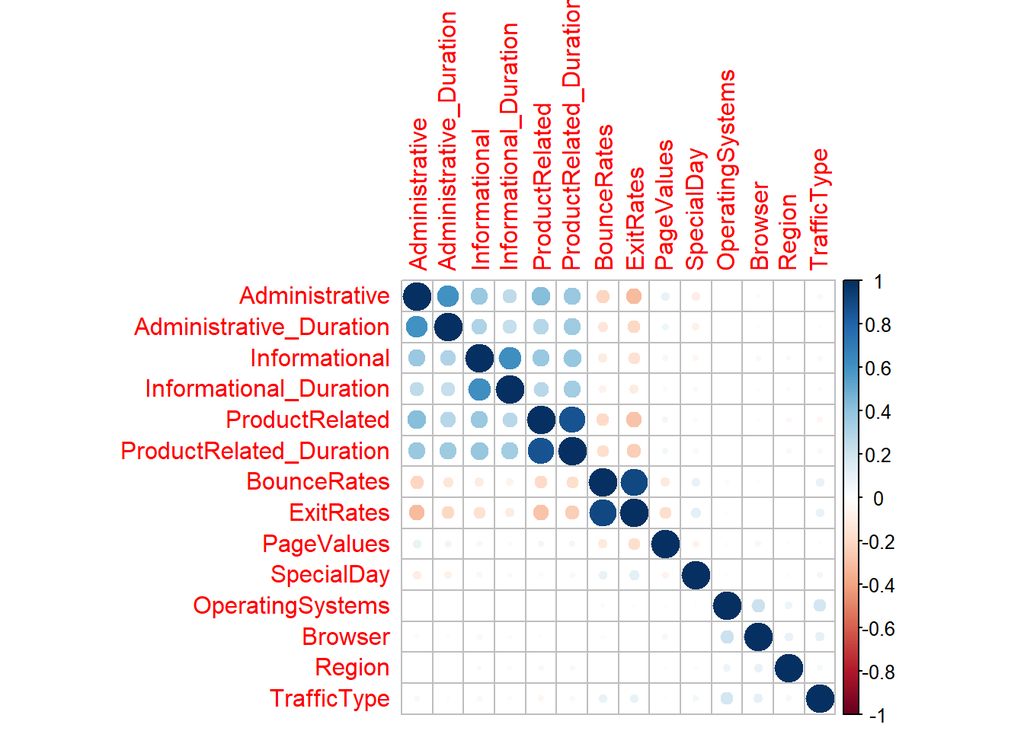

```r
# Installing the correlation plot to visualize the correlation coefficients.
library(corrplot)
corrplot(numerical.cor)
```

- There is a strong positive correlation between ProductRelated_Duration and ProductRelated.
- There is a strong positive correlation between BounceRates and Exit rates.

Correlated values tend to increase the variance in our dataset giving us outliers which can distort summaries of the distribution of the values. We will therefore drop one of the positively correlated features.

```r
# Dropping the correlated features.
numerical$ProductRelated_Duration<-NULL
numerical$BounceRates<-NULL

dim(numerical)
```

```
## [1] 12166    12
```

MULTIVARIATE ANALYSIS

```r
# Performing dimensionality reduction.

df.pca<-prcomp(numerical, center=TRUE, scale.=TRUE)
summary(df.pca)
```

```
## Importance of components:
##                           PC1    PC2    PC3     PC4     PC5    PC6    PC7
## Standard deviation     1.6401 1.1746 1.1031 0.99562 0.98721 0.9638 0.9462
## Proportion of Variance 0.2242 0.1150 0.1014 0.08261 0.08122 0.0774 0.0746
## Cumulative Proportion  0.2242 0.3391 0.4405 0.52315 0.60436 0.6818 0.7564
##                            PC8     PC9    PC10    PC11    PC12
## Standard deviation     0.89312 0.86826 0.79566 0.62400 0.59131
## Proportion of Variance 0.06647 0.06282 0.05276 0.03245 0.02914
## Cumulative Proportion  0.82284 0.88566 0.93842 0.97086 1.00000
```

The proportion of variance tells us the impact of each component on the dataset. PC1 for example explains 22.4% of our dataset. PC12 explains the lowest at 2.9%.

K-MEANS CLUSTERING

K-Means clustering can handle a huge dataset compared to Hierarchical clustering and considering the huge dataset we are using, k-means will be a good clustering algorithm to go with.

However, finding the number of clusters(k-value) is difficult. In our case, we have a large dataset with a lot of variables. To make computation faster, it would be better to go with a small k-value.

```r
# Defining the class which we will be using later to categorize our clusters in the different classes.
numerical.class<-df[,'Revenue']
```

```r
# Scaling our numerical variables so that no particular attribute has more impact on the clustering algorithm than others.
numerical<-scale(numerical)
```

```r
# Applying the clustering algorithm with 3 centroids.
set.seed(42)
result<- kmeans(numerical,3)
```

```r
# Previewing the no. of records in each cluster
result$size
```

```
## [1] 1670 2711 7785
```

The number of values in each cluster.

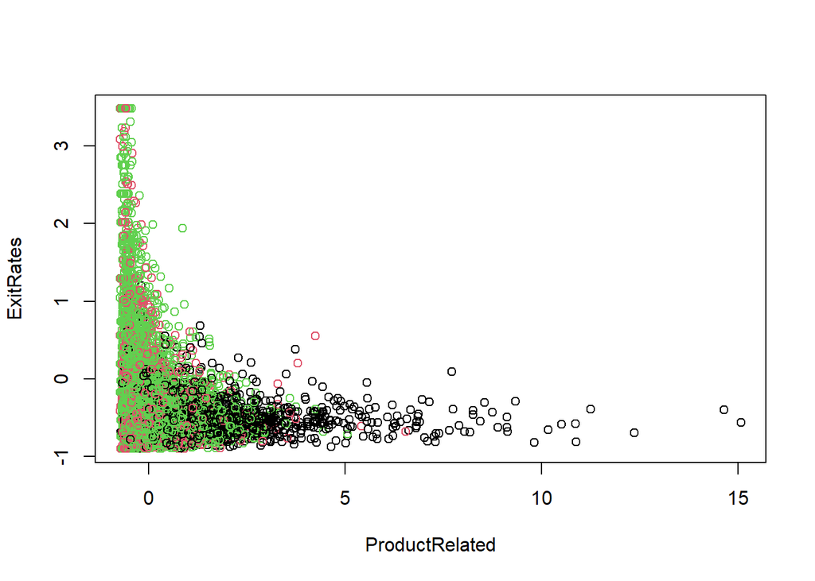

```r
# Plotting to see how ProductRelated and Exit Rates data points have been distributed in clusters.
plot(numerical[,5:6], col = result$cluster)
```

```r
table(result$cluster, numerical.class)
```

```
##    numerical.class
##     FALSE TRUE
##   1  1216  454
##   2  2272  439
##   3  6770 1015
```

HIERARCHICAL CLUSTERING

But unlike K-Means, we do not need to find the the number of clusters required (the k-value), which is usually difficult to predict.

```r
# Applying the dist() function to find the Euclidean distance between observations.
new<-numerical[1:50]
d <- dist(new, method = "euclidean")
```

```r
# Performing hierarchical clustering using the Ward's method
res.hc <- hclust(d, method = "ward.D2" )
```

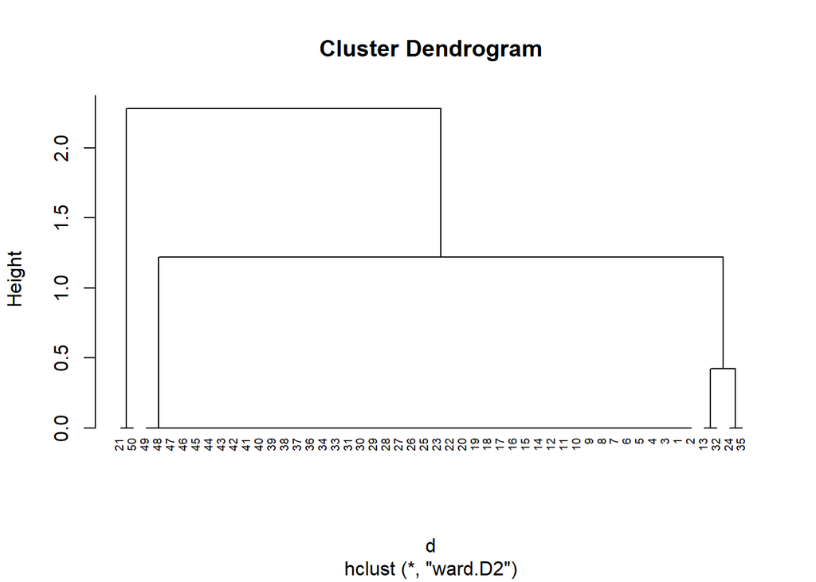

```r
# Plotting the obtained dendrogram
plot(res.hc, cex = 0.6, hang = -1)
```

CONCLUSION

Most people visited the site on weekdays.

Most people visited the site on May and November.

Most people who visited the site did not buy the brand.

Most of the people who visited the site were returning visitors. They had been to the site before.

RECOMMENDATION

Since most people who visited the site did not buy the brand, we should introduce a customer discount to encourage people to buy the brand.

Advertisements of the brand should be made more on the weekdays than on the weekends since most people visit the site on the weekdays.

Since most people who visit the site are returning visitors, we can show appreciation by sending an email thanking the customers who frequently visit the site even if most of them don’t buy the brand. This might encourage them to buy the brand without even telling them to buy it.